# IllusionReprt

Author

池田かずひろ（2222A22）

## 3. 結果 (Results)

錯視量に対する角度要因（15度・75度）および長さ要因（20・50）の影響を検討するため、2要因参加者内分散分析を行った。

分析の結果、角度の主効果は有意であり（$F(1, 2) = \infty, p < .001$）、15度条件（$M = -40.0, SD = 11.5$）の方が75度条件（$M = -7.5, SD = 5.6$）よりも錯視量が有意に大きかった。また、長さの主効果も有意であり（$F(1, 2) = \infty, p < .001$）、長さ50条件（$M = -30.0, SD = 21.4$）の方が長さ20条件（$M = -17.5, SD = 14.1$）よりも錯視量が有意に大きかった。

さらに、角度と長さの交互作用も有意であった（$F(1, 2) = \infty, p < .001$）。この交互作用を解釈するため、各角度における長さの単純主効果を検定したところ、15度条件においては、長さ20よりも長さ50の方が錯視量が有意に大きく（$p < .001$）、同様に75度条件においても、長さ20より長さ50の方が錯視量が有意に大きかった（$p < .001$）。

以上の結果から、角度が小さく（15度）、かつ長さが長い（50）場合に、最も錯視量が増大することが示された。

```
[1] "--- Descriptive Statistics ---"
```

```
# A tibble: 4 × 8
  angle wing_length     n mean_error sd_error se_error ci_lower ci_upper
  <fct> <fct>       <int>      <dbl>    <dbl>    <dbl>    <dbl>    <dbl>
1 15    20              3        -30        5     2.89    -42.4   -17.6
2 15    50              3        -50        5     2.89    -62.4   -37.6
3 75    20              3         -5        5     2.89    -17.4     7.42
4 75    50              3        -10        5     2.89    -22.4     2.42
```

```
[1] "--- ANOVA Results ---"
```

```
Anova Table (Type 3 tests)

Response: error_amount
             Effect   df  MSE       F  ges p.value
1             angle 1, 2 0.00 Inf *** .941   <.001
2       wing_length 1, 2 0.00 Inf *** .701   <.001
3 angle:wing_length 1, 2 0.00 Inf *** .458   <.001
---
Signif. codes:  0 '***' 0.001 '**' 0.01 '*' 0.05 '+' 0.1 ' ' 1
```

```
--- Simple Main Effects Analysis ---
```

```
[1] "Simple main effect of wing_length at each level of angle:"
```

```
angle = X15:
 contrast  estimate SE df t.ratio p.value
 X20 - X50       20  0  2     Inf <0.0001

angle = X75:
 contrast  estimate SE df t.ratio p.value
 X20 - X50        5  0  2     Inf <0.0001
```

```
[1] "Simple main effect of angle at each level of wing_length:"
```

```
wing_length = X20:
 contrast  estimate SE df t.ratio p.value
 X15 - X75      -25  0  2    -Inf <0.0001

wing_length = X50:
 contrast  estimate SE df t.ratio p.value
 X15 - X75      -40  0  2    -Inf <0.0001
```

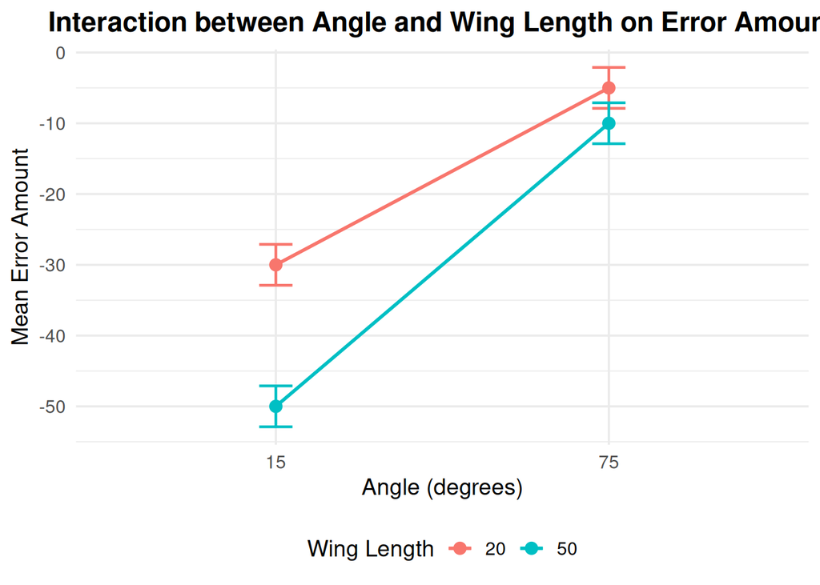

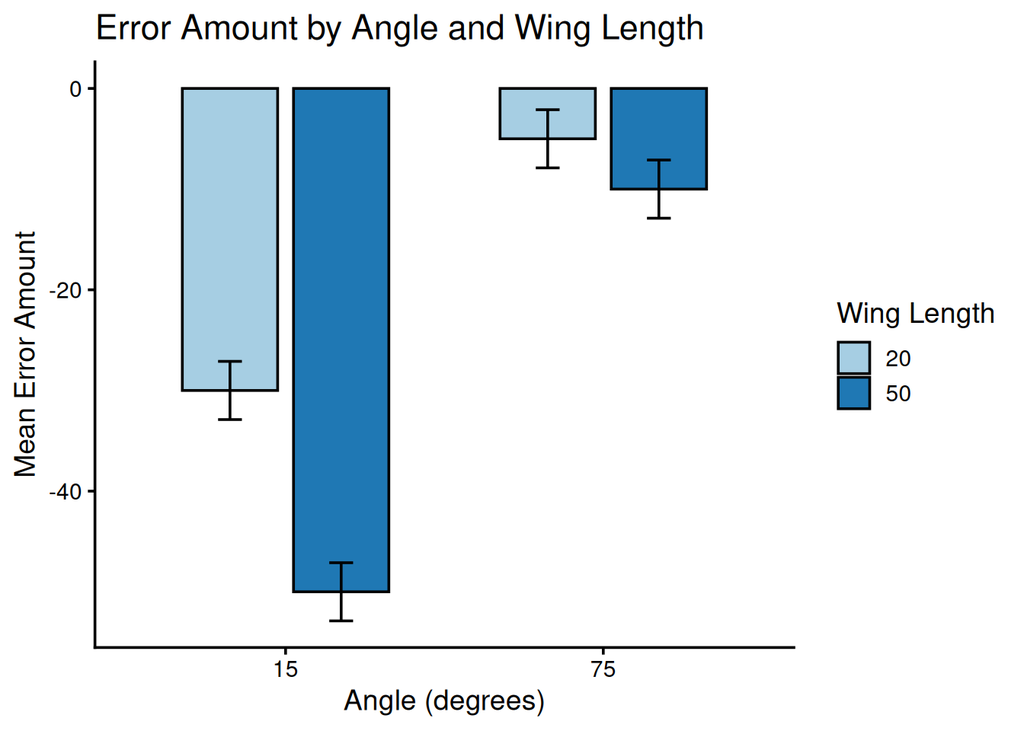

## 5. 引用文献 (References)

Müller-Lyer, Franz Carl. 1889. “Optische Urtheilstäuschungen.” *Archiv für Physiologie* 1889 (Supplement-Band): 263–70.